# Assignment 4

Gracie White

November 12, 2018

## INTRODUCTION

The spiny lobster, *Panulirus interruptus*, is an integral part of the the California kelp forests. A keystone species, the lobsters exert top down control on urchins, and accordingly, the macroalgae that the urchins consume<sup>3</sup>. While research is still being done on the ecosystem dynamics of this predator/prey relationship in the Santa Barbara area, other locations have documented trophic cascades detrimental to kelp forests stemming from excess fishing pressure on the Spiny Lobster<sup>3</sup>.

In addition to ecological importance, the Spiny Lobster also supports a multi-million dollar commercial fishery, and millions more in recreational consumer spending, the third most valuable fishery in area (behind the market squid and Dungeness Crab fisheries)<sup>1,2</sup>. For example, the total 2016 ex-vessel value of the California lobster fishery came to $13,691,364, and brought in an additional estimated $33-$40 million in consumer spending from recreational fishing, diving, and eco-tourism<sup>1</sup>.

```
The State of California has been in charge of managing this fishery for over a century, and while recent regulations seem to have stabilized populations, many are concerned that the heavy fishing of the last century has caused an overall decrease in both size and abundance^3^. If so, then the value of the commercial fishery, and the health of the kelp forests, may be at risk^3^.

The 2016-2017 season had the lowest catch of the last ten fishing seasons, despite an increase in abundance predicted with the Pacific Decadal Oscillation’s warmer waters^2^. The drop in catch was thus unexpected by the Department of Fish and Wildlife. Another 2016-2017 anomaly noticed by researchers was a shift in geographic location. More catch than ever before originated from the Channel Islands, as opposed to the rest of southern California^2^. These anomalies underscore the importance of a robust fisheries management plan, with continued analysis of its effectiveness.
```

Current management is centered around a limited-entry approach. The fishery is only open from October to March, meant to prevent any harvesting during the spawning season<sup>1</sup>. Recreational fishers are also required to have a specific lobstering license in order to participate, and only a certain number of commercial licenses are awarded each season<sup>2</sup>. To further protect lobsters of spawning age, California also enacted an 82.6mm minimum size limit for carapace length. In theory, this limitation should allow lobsters to reproduce for a year or two before reaching the size limit<sup>1</sup>.

Additionally, In 2012, the State of California set up 50 new marine protected areas (MPAs) under the Marine Life Protection Act (MLPA) in the the southern part of the state<sup>1</sup>. These MPAs were implemented specifically to conserve fishery resources, such as providing “safe zones” for the Spiny Lobster to reproduce without any fishing pressure<sup>1</sup>. This was not without controversy, as some argued that the creation of MPAs would only serve to increase fishing pressure elsewhere, in non-MPAs, to the detriment of those ecosystems<sup>1</sup>.

The following report analyzes data between at five Long-Term Ecological Research (LTER) Sites in the Santa Barbara Area, Arroyo Quemado (AQUE), Naples Reef (NAPL), Mohawk Reef (MOHK), Isla Vista (IVEE), Carpinteria (CARP)<sup>4</sup>. Two of the sites, Isla Vista and Naples Reef, were both established as MPAs in 2012. This report will look at the trends in lobster size, overall abundance, and fishing pressure between MPAs and non-MPAs between 2012 and 2017, and suggest potential next steps for monitoring the California Spiny Lobster Fishery.

## DATA AND METHODS

[output not shown]

## RESULTS AND DISCUSSION

*Lobster Abundance and Fishing Pressure*

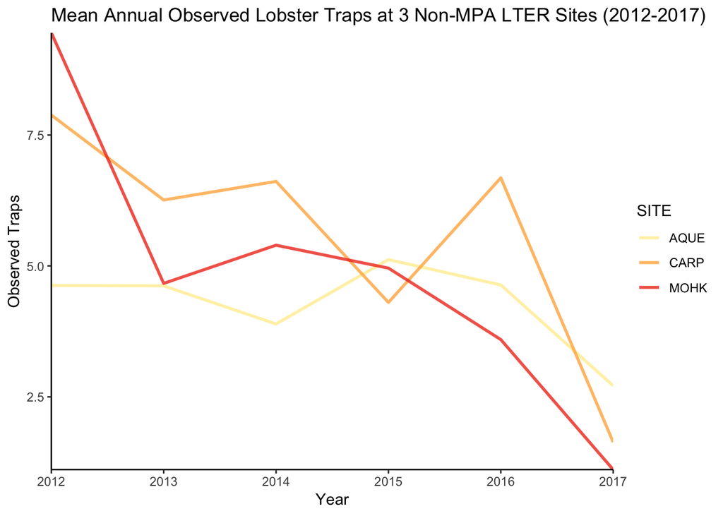

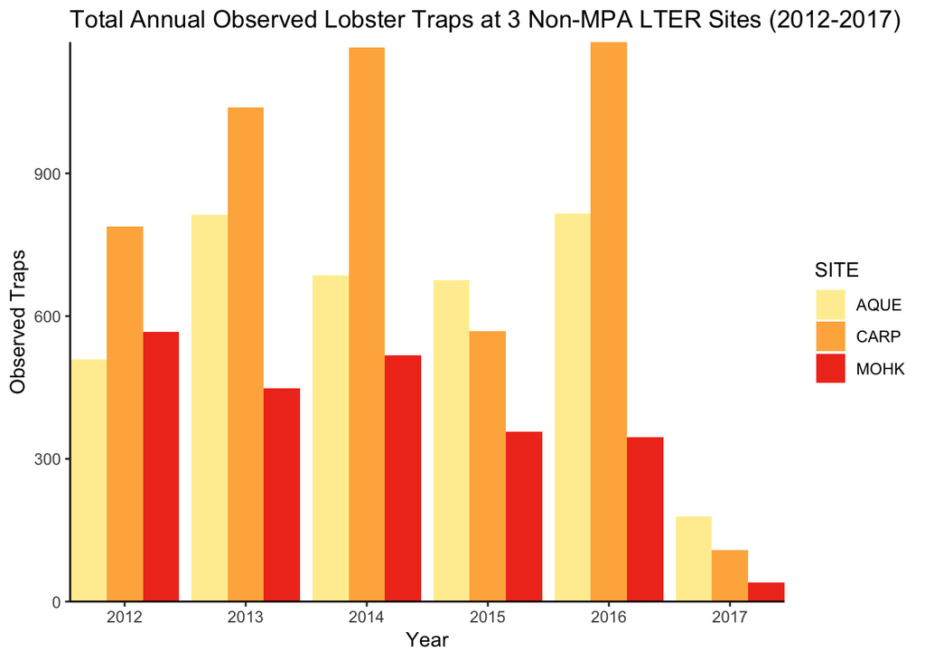

```
## # A tibble: 30 x 4
## # Groups:   SITE, YEAR [30]
##    SITE   YEAR COUNT MPA
##    <chr> <int> <int> <chr>
##  1 AQUE   2012    38 No MPA
##  2 CARP   2012    78 No MPA
##  3 IVEE   2012    26 MPA
##  4 MOHK   2012    83 No MPA
##  5 NAPL   2012     6 MPA
##  6 AQUE   2013    32 No MPA
##  7 CARP   2013    93 No MPA
##  8 IVEE   2013    40 MPA
##  9 MOHK   2013    15 No MPA
## 10 NAPL   2013    63 MPA
## # ... with 20 more rows
```

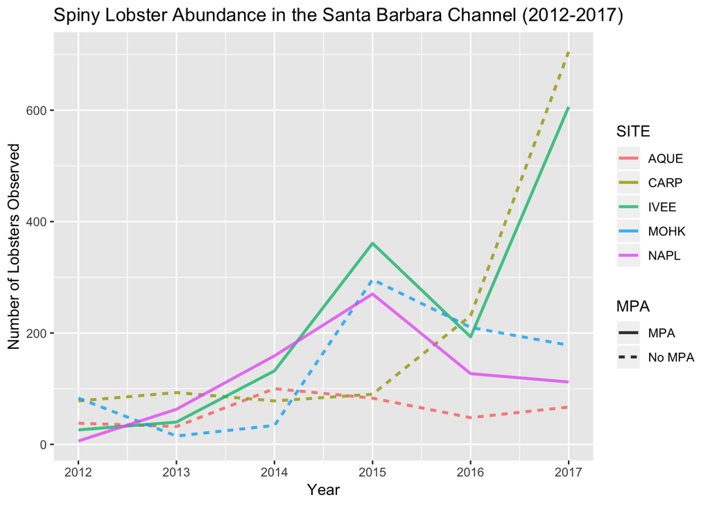

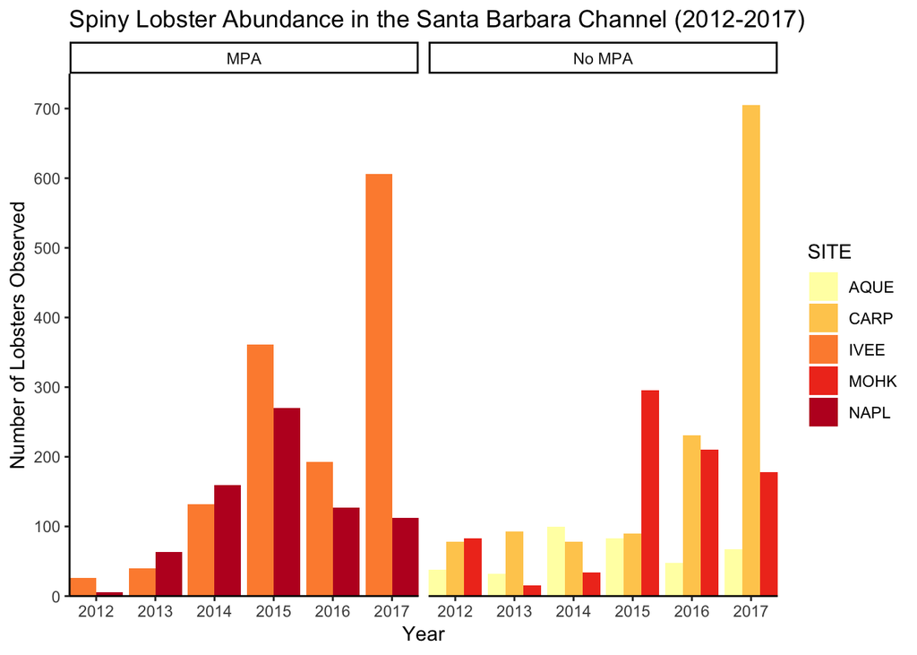

*Mean Lobster Size in 2017*

```
## Levene's Test for Homogeneity of Variance (center = median)
##         Df F value    Pr(>F)
## group    4  8.3893 1.065e-06 ***
##       1663
## ---
## Signif. codes:  0 '***' 0.001 '**' 0.01 '*' 0.05 '.' 0.1 ' ' 1
```

```
##               Df Sum Sq Mean Sq F value Pr(>F)
## SITE           4   2355   588.6   3.424 0.0085 **
## Residuals   1663 285871   171.9
## ---
## Signif. codes:  0 '***' 0.001 '**' 0.01 '*' 0.05 '.' 0.1 ' ' 1
```

```
##   Tukey multiple comparisons of means
##     95% family-wise confidence level
##
## Fit: aov(formula = SIZE ~ SITE, data = lsize_expanded)
##
## $SITE
##                 diff         lwr      upr     p adj
## CARP-AQUE -1.6657352 -6.24294710 2.911477 0.8582355
## IVEE-AQUE -2.4433772 -7.05292315 2.166169 0.5968998
## MOHK-AQUE -1.8955224 -7.02720717 3.236162 0.8514711
## NAPL-AQUE  2.3366205 -3.19311600 7.866357 0.7775633
## IVEE-CARP -0.7776420 -2.76097123 1.205687 0.8216104
## MOHK-CARP -0.2297872 -3.23309697 2.773523 0.9995765
## NAPL-CARP  4.0023556  0.36042398 7.644287 0.0228728
## MOHK-IVEE  0.5478548 -2.50450730 3.600217 0.9882889
## NAPL-IVEE  4.7799976  1.09751057 8.462485 0.0037001
## NAPL-MOHK  4.2321429 -0.08607271 8.550358 0.0579286
```

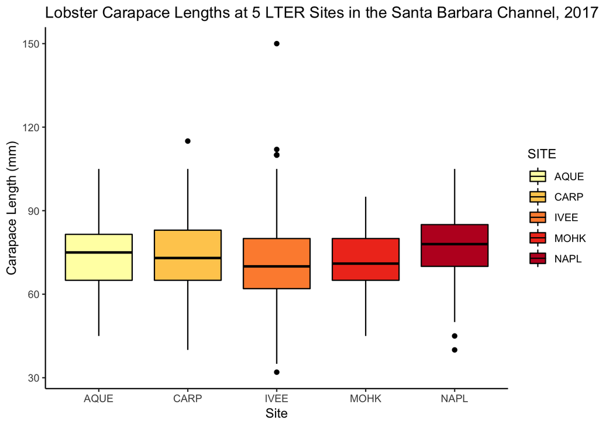

```
## $statistics
##    MSerror   Df     Mean       CV
##   171.9009 1663 72.25839 18.14474
##
## $parameters
##    test name.t ntr StudentizedRange alpha
##   Tukey   SITE   5         3.861894  0.05
##
## $means
##          SIZE       std   r Min Max Q25 Q50  Q75
## AQUE 73.89552 11.891090  67  45 105  65  75 81.5
## CARP 72.22979 13.209134 705  40 115  65  73 83.0
## IVEE 71.45215 14.320079 606  32 150  62  70 80.0
## MOHK 72.00000  9.280318 178  45  95  65  71 80.0
## NAPL 76.23214 11.388300 112  40 105  70  78 85.0
##
## $comparison
## NULL
##
## $groups
##          SIZE groups
## NAPL 76.23214      a
## AQUE 73.89552     ab
## CARP 72.22979      b
## MOHK 72.00000      b
## IVEE 71.45215      b
##
## attr(,"class")
## [1] "group"
```

```
## # A tibble: 5 x 4
##   SITE  count  mean    sd
##   <chr> <int> <dbl> <dbl>
## 1 AQUE     67  73.9 11.9
## 2 CARP    705  72.2 13.2
## 3 IVEE    606  71.4 14.3
## 4 MOHK    178  72    9.28
## 5 NAPL    112  76.2 11.4
```

[output not shown]

#### Table 1. Lobster Size at 5 LTER Sites in the Santa Barbara Channel, 2017

Sample means of measured carapce lengths ± 1 standard deviation (mm) of lobsters in 2017. Count represents the number of lobsters measured at each site. Like letters indicate means that do not differ significantly by one-way ANOVA (F(4) = 3.424, p = 0.0085, $\alpha$ = 0.05) with Tukey’s HSD ($\alpha$ = 0.05).

*Changes in Lobster Size from 2012-2017 in MPA and non-MPA sites*

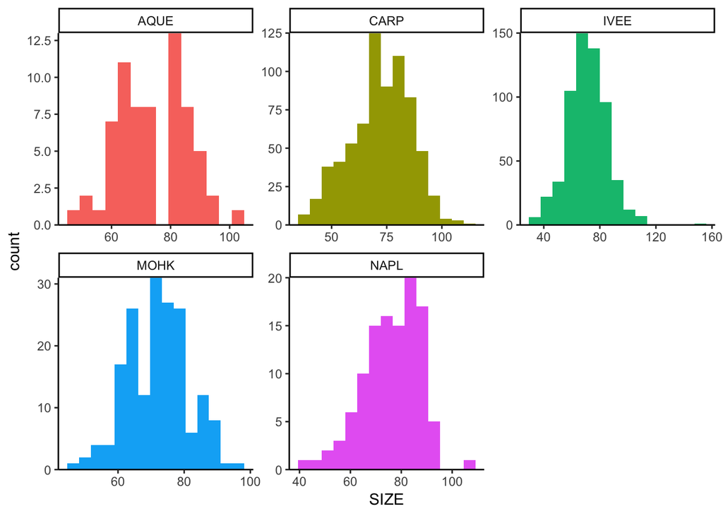

```
##
##  F test to compare two variances
##
## data:  IVEE_2012 and IVEE_2017
## F = 0.71311, num df = 25, denom df = 605, p-value = 0.307
## alternative hypothesis: true ratio of variances is not equal to 1
## 95 percent confidence interval:
##  0.4322948 1.3698611
## sample estimates:
## ratio of variances
##           0.713111
```

```
##
##  Two Sample t-test
##
## data:  IVEE_2012 and IVEE_2017
## t = -1.885, df = 630, p-value = 0.0599
## alternative hypothesis: true difference in means is not equal to 0
## 95 percent confidence interval:
##  -10.9750916   0.2246473
## sample estimates:
## mean of x mean of y
##  66.07692  71.45215
```

```
##
## Cohen's d
##
## d estimate: -0.3775177 (small)
## 95 percent confidence interval:
##         inf         sup
## -0.77136540  0.01633002
```

```
##
##      Two-sample t test power calculation
##
##               n = 632
##               d = 0.377
##       sig.level = 0.05
##           power = 0.9999989
##     alternative = two.sided
##
## NOTE: n is number in *each* group
```

```
##
##  F test to compare two variances
##
## data:  NAPL_2012 and NAPL_2017
## F = 1.064, num df = 5, denom df = 111, p-value = 0.7685
## alternative hypothesis: true ratio of variances is not equal to 1
## 95 percent confidence interval:
##  0.3966019 6.4626426
## sample estimates:
## ratio of variances
##           1.064048
```

```
##
##  Two Sample t-test
##
## data:  NAPL_2012 and NAPL_2017
## t = -0.67636, df = 116, p-value = 0.5002
## alternative hypothesis: true difference in means is not equal to 0
## 95 percent confidence interval:
##  -12.697051   6.232765
## sample estimates:
## mean of x mean of y
##  73.00000  76.23214
```

```
##
## Cohen's d
##
## d estimate: -0.2834216 (small)
## 95 percent confidence interval:
##        inf        sup
## -1.1141889  0.5473456
```

```
##
##      Two-sample t test power calculation
##
##               n = 118
##               d = 0.283
##       sig.level = 0.05
##           power = 0.5811829
##     alternative = two.sided
##
## NOTE: n is number in *each* group
```

```
##
##  F test to compare two variances
##
## data:  AQUE_2012 and AQUE_2017
## F = 0.72863, num df = 37, denom df = 66, p-value = 0.2986
## alternative hypothesis: true ratio of variances is not equal to 1
## 95 percent confidence interval:
##  0.419142 1.327868
## sample estimates:
## ratio of variances
##          0.7286314
```

```
##
##  Two Sample t-test
##
## data:  AQUE_2012 and AQUE_2017
## t = -1.2622, df = 103, p-value = 0.2097
## alternative hypothesis: true difference in means is not equal to 0
## 95 percent confidence interval:
##  -7.445357  1.654312
## sample estimates:
## mean of x mean of y
##  71.00000  73.89552
```

```
##
## Cohen's d
##
## d estimate: -0.2563169 (small)
## 95 percent confidence interval:
##        inf        sup
## -0.6606014  0.1479675
```

```
##
##      Two-sample t test power calculation
##
##               n = 105
##               d = 0.256
##       sig.level = 0.05
##           power = 0.4548344
##     alternative = two.sided
##
## NOTE: n is number in *each* group
```

```
##
##  F test to compare two variances
##
## data:  CARP_2012 and CARP_2017
## F = 1.2244, num df = 77, denom df = 704, p-value = 0.2043
## alternative hypothesis: true ratio of variances is not equal to 1
## 95 percent confidence interval:
##  0.896208 1.750406
## sample estimates:
## ratio of variances
##           1.224405
```

```
##
##  Two Sample t-test
##
## data:  CARP_2012 and CARP_2017
## t = 1.3361, df = 781, p-value = 0.1819
## alternative hypothesis: true difference in means is not equal to 0
## 95 percent confidence interval:
##  -0.998958  5.257332
## sample estimates:
## mean of x mean of y
##  74.35897  72.22979
```

```
##
## Cohen's d
##
## d estimate: 0.1594364 (negligible)
## 95 percent confidence interval:
##         inf         sup
## -0.07493682  0.39380971
```

```
##
##      Two-sample t test power calculation
##
##               n = 783
##               d = 0.159
##       sig.level = 0.05
##           power = 0.8818203
##     alternative = two.sided
##
## NOTE: n is number in *each* group
```

```
##
##  F test to compare two variances
##
## data:  MOHK_2012 and MOHK_2017
## F = 1.3015, num df = 82, denom df = 177, p-value = 0.1509
## alternative hypothesis: true ratio of variances is not equal to 1
## 95 percent confidence interval:
##  0.9085131 1.9131403
## sample estimates:
## ratio of variances
##           1.301535
```

```
##
##  Two Sample t-test
##
## data:  MOHK_2012 and MOHK_2017
## t = 4.0689, df = 259, p-value = 6.276e-05
## alternative hypothesis: true difference in means is not equal to 0
## 95 percent confidence interval:
##  2.710776 7.795248
## sample estimates:
## mean of x mean of y
##  77.25301  72.00000
```

```
##
##  Two Sample t-test
##
## data:  MOHK_2012 and MOHK_2017
## t = 4.0689, df = 259, p-value = 3.138e-05
## alternative hypothesis: true difference in means is greater than 0
## 95 percent confidence interval:
##  3.121847      Inf
## sample estimates:
## mean of x mean of y
##  77.25301  72.00000
```

```
##
## Cohen's d
##
## d estimate: 0.5408116 (medium)
## 95 percent confidence interval:
##       inf       sup
## 0.2749635 0.8066597
```

```
##
##      Two-sample t test power calculation
##
##               n = 261
##               d = 0.5408
##       sig.level = 0.05
##           power = 0.999987
##     alternative = two.sided
##
## NOTE: n is number in *each* group
```

```
## # A tibble: 10 x 5
## # Groups:   SITE [?]
##    SITE   YEAR mean_lobs_size    sd sample_size
##    <chr> <int>          <dbl> <dbl>       <int>
##  1 AQUE   2012           71   10.2           38
##  2 AQUE   2017           73.9 11.9           67
##  3 CARP   2012           74.4 14.6           78
##  4 CARP   2017           72.2 13.2          705
##  5 IVEE   2012           66.1 12.1           26
##  6 IVEE   2017           71.5 14.3          606
##  7 MOHK   2012           77.3 10.6           83
##  8 MOHK   2017           72    9.28         178
##  9 NAPL   2012           73   11.7            6
## 10 NAPL   2017           76.2 11.4          112
```

|  | Measured Lobster Carapace Length (mm) Mean ± Standard Deviation 2012 | Measured Lobster Carapace Length (mm) Mean ± Standard Deviation 2017 | Measured Lobster Carapace Length (mm) Difference |
| --- | --- | --- | --- |
| **MPA** |  |  |  |
| IVEE | 66.1 ± 12.1 (n = 26) | 71.5 ± 14.3 (n = 606) | 5.4 |
| NAPL | 73 ± 11.8 (n = 6) | 76.2 ± 11.4 (n = 112) | 3.2 |
| **Non-MPA** |  |  |  |
| AQUE | 71 ± 10.2 (n = 38) | 73.9 ± 11.9 (n = 67) | 2.9 |
| CARP | 74.4 ± 14.6 (n = 78) | 72.2 ± 13.2 (n = 705) | -2.2 |
| MOHK | 77.3 ± 10.6 (n = 83) | 72.0 ± 9.3 (n = 178) | -5.3 |

#### Table 2. Change in Lobster Size at 5 LTER Sites in the Santa Barbara Channel between 2012 and 2017.

Sample means of measured carapce lengths ± 1 standard deviation (mm) of lobsters in 2012 and 2017. The number of lobsters measured at each site in each year is listed as (n = ss). Two-Sample Student T-Tests were performed comparing mean lobster size at each site in 2012 and 2017. The only significant difference in mean lobster size from 2012 to 2017 was found at MOHK (t(259) = 4.069, p <.001, $\alpha$ = 0.05) The actual change in mean carapace length (mm) is described in the “difference” column.

*Legal and Illegal Lobster Trapping in 2017*

```
## # A tibble: 5 x 2
##   `Above Legal Minimum` `Below Legal Minimum`
## *                 <int>                 <int>
## 1                    16                    51
## 2                   179                   526
## 3                   130                   476
## 4                    24                   154
## 5                    37                    75
```

```
##
##  Pearson's Chi-squared test
##
## data:  lsize_prop_table
## X-squared = 18.497, df = 4, p-value = 0.0009864
```

#in console, running lsize_x2$stdres to see which sites differ significantly: Above Legal Minimum Below Legal Minimum AQUE 0.1464223 -0.1464223 CARP 1.8631463 -1.8631463 IVEE -1.2357993 1.2357993 MOHK -3.2327773 3.2327773 NAPL 2.5706474 -2.5706474

Standardized residuals greater than |2| indicate significance (I think?)

### So, we can say that the proportions between legal/illegal lobster size is differant at MOHK and NAPL. At MOHK, 87% of lobsters observed were smaller than the legal limit. At NAPL (an MPA), only 66% of lobsters were below the legal limit. The other three sites had between 74-78% of their lobsters below the legal size limit.

|  | Count (Lobsters) | Proportion of Lobsters Measured Carapce Length Illegal (< 82.6 mm) | Proportion of Lobsters Measured Carapce Length Legal (> 82.6 mm) |
| --- | --- | --- | --- |
| **MPA** |  |  |  |
| IVEE | 606 | 0.79 | 0.21 |
| NAPL | 112 | 0.67 | 0.33 |
| **Non-MPA** |  |  |  |
| AQUE | 67 | 0.76 | 0.24 |
| CARP | 705 | 0.75 | 0.25 |
| MOHK | 178 | 0.87 | 0.13 |

## CONCLUSION

The California Spiny Lobster, a keystone species through the california kelp forest ecosystems, also supports an economically important commercial and recreational fishery. In order to preserve lobster populations, California established multiple marine protected areas (MPAs) in 2012 to create “safe zones” for lobsters to spawn undisturbed by fishing pressure. This report aims to analyze the differences in lobster size, abundance, and fishing pressure by site, specifically comparing the differences between MPA sites and non-MPA sites. The following statements summarize the findings of this report:

Statement 1 Fishing pressure is decreasing over time, and severly decreased in 2017. There is a spike in lobster abundance in 2015, and a drop in 2016. 2017 lobster abundance then increases again. Statement 2 By site lobster sizes in 2017. NAPL has the largest mean lobster size. A one-way anova was performed to compare mean carapass length in lobsters across sites. There was a significant difference. A post-hoc TUKEY HSD was performed to make pairwise comaparisons. NAPL-IVEE and NAPL-CARP had significantly different means. Statement 3 Mean lobster sizes were compared for each site between 2012 and 2017. F tests for equal variances were ran (equal for all) and thus student t-tests were used to compare means across years. Effect size and power tests were also ran for each t-test. The only significant result for a difference in mean size between the two years is at MOHK. A one-way t-test was ran and sigfnicant that mean lobster size decreased in 2017 from 2012. While not statistically significant, the observed sample means show a small increase in lobster size in the MPA sites & AQUE, and a decrease in mean lobster size at CARP and MOHK (mohk is stat. sig.) Statement 4 Compared proportions of legal vs. illegal lobsters (based on carapace length) at each site in 2017. Proportions between legal and illegal lobster size is significantly different at MOHK and NAPL. At MOHK, 87% of lobsters observed were smaller than the legal limit. At NAPL, only 66% of lobsters were smaller than the legal limit. The other three sites, saw 74-78% of the lobsters smaller than the legal size limit. A chi-square test for proportions and compared standardized residuals.

In order to stay up to date on management best practices, this report should be updated yearly with new data, especially since many variables other than fishing pressure can have a large and immediate impact on loster populations, such as anomalies in water temperature from the Pacific Decadal Oscillation. Fishery managers should know as soon as possible when there are major disturbances to lobster populations in order to make well-informed decisions about how to optimize the lobster fishery for both economic value and conservation. Given that the establishment of the southern California MPAs are fairly recent, longer term monitoring is needed to determine if they boost net lobster populations, or create detrimental pressure to non-MPA zones. Studies such as the SBC LTER will be essential in monitoring these changes going forward.